# Gapminder: esperanza de vida y desarrollo económico

2026-08-12

## Objetivo del proyecto

### Objetivo principal

Analizar la evolución de la esperanza de vida a nivel mundial y estudiar su relación con el desarrollo económico entre 1952 y 2007.

### Objetivos específicos

- Analizar la evolución temporal de la esperanza de vida.
- Comparar la esperanza de vida entre continentes.
- Estudiar la relación entre PIB per cápita y esperanza de vida.
- Resumir los principales indicadores del conjunto de datos.

## Datos

La base de datos utilizada es **Gapminder**, que contiene indicadores socioeconómicos de diferentes países a lo largo del tiempo.

### Características principales

- **142 países**
- **5 continentes**
- Periodo: **1952–2007**
- Variables principales:
  - País
  - Continente
  - Año
  - Esperanza de vida
  - Población
  - PIB per cápita

Los datos fueron previamente explorados y depurados mediante código R.

## Evolución de la esperanza de vida

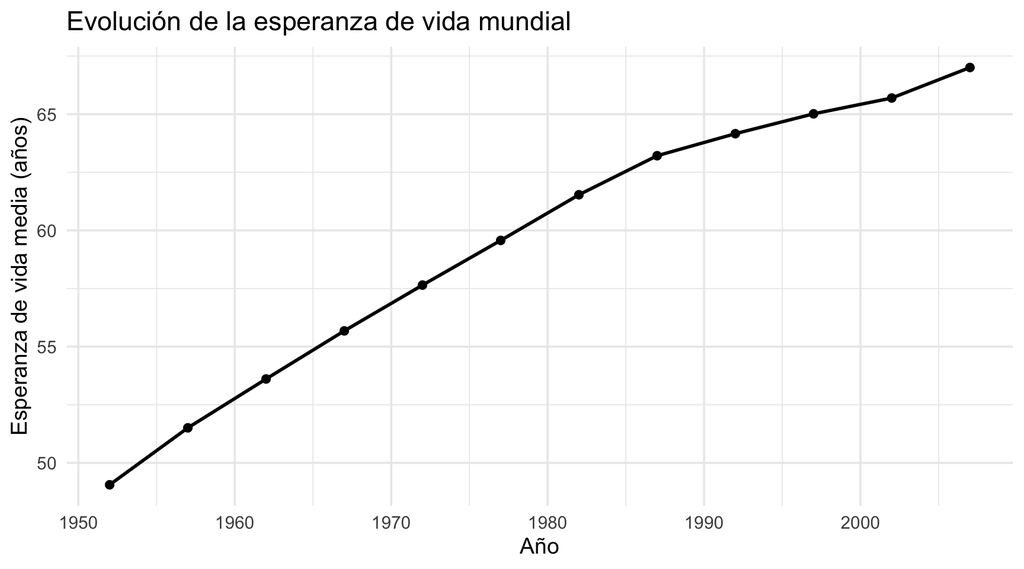

## Evolución de la esperanza de vida

### Principal resultado

La esperanza de vida media aumentó de:

**49,1 años en 1952**

a

**67,0 años en 2007**

Esto supone una mejora de aproximadamente **17,9 años** durante el periodo estudiado.

### Interpretación

Se observa una tendencia ascendente clara a lo largo de todo el periodo.

## Diferencias entre continentes

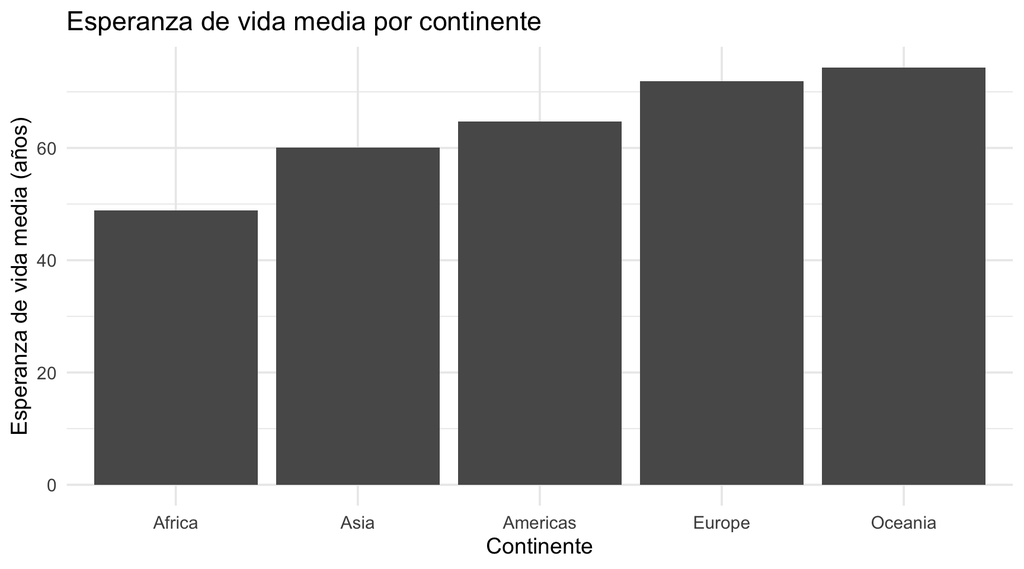

## PIB y esperanza de vida

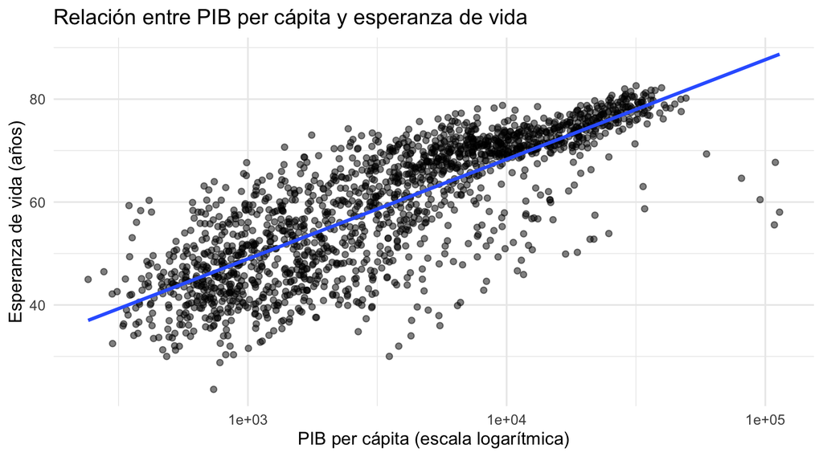

## PIB y esperanza de vida

### Resultado principal

La correlación entre PIB per cápita y esperanza de vida es:

## 0.584

### Interpretación

Existe una **asociación positiva moderada** entre ambas variables.

En general, los países con un PIB per cápita más elevado tienden a presentar una mayor esperanza de vida.

**Importante:** correlación no implica causalidad.

## Indicadores principales

| Indicador | Valor |
| --- | --- |
| Países | 142.000 |
| Continentes | 5.000 |
| Año inicial | 1952.000 |
| Año final | 2007.000 |
| Esperanza de vida inicial | 49.100 |
| Esperanza de vida final | 67.000 |
| PIB per cápita medio | 7215.000 |
| Correlación PIB - vida | 0.584 |

## Principales hallazgos

### 1. Mejora de la esperanza de vida

La esperanza de vida mundial aumentó considerablemente entre 1952 y 2007.

### 2. Diferencias geográficas

La esperanza de vida media presenta diferencias importantes entre continentes.

### 3. Relación con el desarrollo económico

Existe una asociación positiva entre PIB per cápita y esperanza de vida.

### 4. Análisis reproducible

Todos los resultados y gráficos se generan mediante código R.

## Conclusiones

### ¿Qué hemos encontrado?

- La esperanza de vida mundial aumentó de **49,1 a 67,0 años**.
- Existen diferencias de esperanza de vida entre continentes.
- El PIB per cápita presenta una relación positiva con la esperanza de vida.
- La correlación observada es de aproximadamente **0,584**.

### Conclusión general

Los países con mayores niveles de desarrollo económico presentan, en promedio, una mayor esperanza de vida.

Sin embargo, estos resultados son **descriptivos y correlacionales** y no permiten establecer causalidad.

## Reproducibilidad

El proyecto se ha desarrollado utilizando:

**RStudio + R + GitHub + R Markdown + Shiny**

### Estructura del proyecto

```
R/
├── 01_limpieza.R
└── 02_analisis.R

data/
└── gapminder_limpio.csv

dashboard/
└── app.R

informe/
└── informe_gapminder.Rmd

presentacion/
└── presentacion_gapminder.Rmd
```

Todo el análisis puede ser reproducido a partir del código y los datos incluidos en el repositorio.

## Gracias

## Gapminder

### Esperanza de vida y desarrollo económico

**Gemma Planas**